# Quarantine Tribute Tips Facebook Page Text Analysis

From social media to product reviews, text is an increasingly important type of data across applications. In many instances, text is replacing other forms of unstructured data due to how inexpensive and current it is. However, to take advantage of everything that text has to offer, you need to know how to think about, clean, summarize, and model text.

# Ingress

## Load dependecies

```r
library(tidyverse)
library(tidytext)
library(tm)
library(topicmodels)
library(textdata)
library(RColorBrewer)
library(reshape2)
library(wordcloud)
```

**The data were processed using:**

- `R-4.2.1 language` (R Core Team)
- `RStudio 2022.02.3+492 "Prairie Trillium" Release (1db809b8323ba0a87c148d16eb84efe39a8e7785, 2022-05-20) for Windows` (RStudio Team)
- `tidyverse` (Wickham et al.)
- `tidytext` (Silge and Robinson)
- `tm`(Feinerer et al.)
- `topicmodels`(Grün and Hornik)
- `textdata`(Hvitfeldt)
- `RColorBrewer`(Neuwirth)
- `reshape2`(Wickham)
- `wordcloud`(Fellows)

## Load datasets

```r
qtt_data <- list.files(pattern = "*.csv") %>%
  map_df(~read_csv(.))
```

## Create appropriate column names

```r
colnames(qtt_data)[1]<- "url"
colnames(qtt_data)[2]<- "username"
colnames(qtt_data)[3]<- "post_text"
colnames(qtt_data)[4]<- "timestamp"
colnames(qtt_data)[5]<- "images"
colnames(qtt_data)[6]<- "gif"
colnames(qtt_data)[7]<- "videos"
colnames(qtt_data)[8]<- "poll"
colnames(qtt_data)[9]<- "reacts"
colnames(qtt_data)[10]<- "comments"
colnames(qtt_data)[11]<- "comment_url"
colnames(qtt_data)[12]<- "commenter1"
colnames(qtt_data)[13]<- "comment_text"
colnames(qtt_data)[14]<- "reply_url"
colnames(qtt_data)[15]<- "commenter2"
colnames(qtt_data)[16]<- "reply_text"
```

## Seperate timestamp to date and time

```r
qtt_data <- qtt_data %>%
  mutate(datetime = timestamp) %>%
  separate(datetime, sep = " ", into = c("date", "time"))
```

## Seperate date to year, month, and day

```r
qtt_data <- qtt_data %>%
  separate(date, sep = "\\/", into = c("month", "day", "year")) %>%
  mutate_at(c("month", "day", "year"), as.numeric)
```

## Recode numerical months to text

```r
qtt_data$month <- as.factor(qtt_data$month)
qtt_data$month <- recode(qtt_data$month, '1' = 'January', '2' = 'February', '3' = 'March', '4' = 'April', '5' = 'May', '6' = 'June', '7' = 'July', '8' = 'August', '9' = 'September', '10' = 'October', '11' = 'November', '12' = 'December')
```

```r
qtt_data$timestamp <- strptime(qtt_data$timestamp, "%m/%d/%Y %H:%M")
```

## Creating a unique id

```r
qtt_data <- qtt_data %>%
  mutate(id = row_number())
```

# Preparing **QTT FB posts** for analysis

## Tokenizing text

We impose structure on text by splitting each post or comments into separate words. We don’t care about the syntax or structure of the post or comments, we’re simply cutting out each word in each post or comments and mixing them up in a bag: a bag of words! Each separate body of text is a document; in this case, the post or comments. Each unique word is known as a term. Every occurrence of a term known as a token; thus cutting up documents into words is known as tokenizing.

```r
qtt_data$post_text %>%
  head()
```

```
[1] "HELLO TRIBUTES!\n\nThis group is for the kids who became the tributes of their families to the outside world.\n\nYou can post how to pick fresh produce in the grocery or market, how to properly clean the house, how to keep your senior citizens parents from going out, saan bukas na supermarket a…
[2] "HELLO TRIBUTES!\n\nThis group is for the kids who became the tributes of their families to the outside world.\n\nYou can post how to pick fresh produce in the grocery or market, how to properly clean the house, how to keep your senior citizens parents from going out, saan bukas na supermarket a…
[3] "IF maghhoard ng perishable fruits and vegetables from the market, wag kang pipili ng puro hinog kasi baka masira lang most kung hindi naman gagamitin agad-agad.\n\nI use the 30% hinog 70% pahinog pa lang ratio para mababa lang ang possible waste from it"
[4] "IF maghhoard ng perishable fruits and vegetables from the market, wag kang pipili ng puro hinog kasi baka masira lang most kung hindi naman gagamitin agad-agad.\n\nI use the 30% hinog 70% pahinog pa lang ratio para mababa lang ang possible waste from it"
[5] "#TitoTips for buying meat!!\n1. Buy the large cuts like kasim or pigue. They are cheaper than the smaller cuts which are practically made out of the same thing! You can ask the butchers to slice the large cuts as long as you buy the whole thing.\n2. Mind the brands. Supermarkets like SM or Robi…
[6] "#TitoTips for buying meat!!\n1. Buy the large cuts like kasim or pigue. They are cheaper than the smaller cuts which are practically made out of the same thing! You can ask the butchers to slice the large cuts as long as you buy the whole thing.\n2. Mind the brands. Supermarkets like SM or Robi…
```

### Using the distinct()

Given the structure of our post_text dataset, we need to delete the duplicated values to avoid an inflated word count. This is something that can be addressed by the `distinct()`. The `.keep_all = TRUE` attribute will retain all other variables.

```r
qtt_data %>%
  distinct(post_text)
```

| post_text |
| --- |
| HELLO TRIBUTES!\n\nThis group is for the kids who became the tributes of their families to the outside world.\n\nYou can post how to pick fresh produce in the grocery or market, how to properly clean … |
| IF maghhoard ng perishable fruits and vegetables from the market, wag kang pipili ng puro hinog kasi baka masira lang most kung hindi naman gagamitin agad-agad.\n\nI use the 30% hinog 70% pahinog pa l… |
| #TitoTips for buying meat!!\n1. Buy the large cuts like kasim or pigue. They are cheaper than the smaller cuts which are practically made out of the same thing! You can ask the butchers to slice the l… |
| #TitoTips |
| GROCERY/PALENGKE TIPS\n\nIto mga natutunan ko sa mama ko haha pero di ko sinasabing best pero feel ko okay naman kasi laking bukid din siya. Masaya mamalengke haha.\n\n-wag bibili ng frozen na meat sa… |
| Can someone post the opening & closing time of groceries near you?\nBusiness hours - grocery name - location\n\nNautusan kasi ako mag grocery kasi ako bukas 😢😬 |
| Can someone post the opening & closing time of groceries near you?\nBusiness hours - grocery name - location\n\nNautusan kasi ako mag grocery kasi ako bukas 😢😬\n\nRobinsons Supermarket\nAugust 5, 2020… |
| HGTV.COM\nFreezing Vegetables |
| Groceries arranged from lowest to highest price point:\n\nPuregold\nLandmark\nShopwise\nRustans\nSM Hypermarket\n\n-\nMay point in my life (2018) na sobrang fave ko Loacker kaya nag-compare ako ng pri… |
| Eggs! Mas safe to bring your own lalagyan (we use the same box na pinaglagyan ng mga tetra juice pack) para di dumadagdag sa kalat sa bahay yung box.\n\nYung mga eggs that look like parts of them are … |

[output cut: 990 more lines]

### Using unnest_tokens()

After loading the `tidytext` package, tokenizing is as simple as using the `unnest_tokens()` function. After specifying the input data frame, we provide the name of the column of words we’re creating by tokenizing followed by the name of the column with the text we want to tokenize. As a bonus, `unnest_tokens()` has done some cleaning for us: punctuation is gone, each word is lowercase, and white space has been removed.

```r
qtt_data %>%
  distinct(post_text, .keep_all = TRUE) %>%
  unnest_tokens(word, post_text) %>%
  select(id, word)
```

| id | word |
| --- | --- |
| 1 | hello |
| 1 | tributes |
| 1 | this |
| 1 | group |
| 1 | is |
| 1 | for |
| 1 | the |
| 1 | kids |
| 1 | who |
| 1 | became |

[output cut: 990 more lines]

### Counting words

Now that we have imposed a tidy structure on the text, we can count words using the `count()` function. To make it easy to read the counts, we use the `arrange()` verb, and the `desc()` helper function. You shouldn’t be surprised to see that the most commonly used words are just common words like **“na”** that doesn’t give much insight into the content of the post or comments. We need to do some additional cleaning before our word counts will be informative.

```r
qtt_data %>%
  distinct(post_text, .keep_all = TRUE) %>%
  unnest_tokens(word, post_text) %>%
  count(word) %>%
  arrange(desc(n))
```

| word | n |
| --- | --- |
| na | 44863 |
| sa | 41156 |
| to | 37436 |
| and | 34875 |
| the | 34513 |
| ng | 30899 |
| po | 30307 |
| for | 22555 |
| ko | 21544 |
| of | 19838 |

[output cut: 990 more lines]

### Using anti_join()

These common and uninformative words are known as stop words and we’d like to remove them from our tidied data frame. A set of functions in `dplyr` comes in handy. These are known as *joins*, and as the name suggests, they are used to join two data frames together based on one or more matching columns. The join we want is called an `anti_join()`. `In an anti_join()`, a row in the data frame on the left is retained as long as the value in the matching column isn’t shared by the data frame on the right.

```r
qtt_data %>%
  distinct(post_text, .keep_all = TRUE) %>%
  unnest_tokens(word, post_text) %>%
  anti_join(stop_words) %>%
  count(word) %>%
  arrange(desc(n))
```

| word | n |
| --- | --- |
| na | 44863 |
| sa | 41156 |
| ng | 30899 |
| po | 30307 |
| ko | 21544 |
| ang | 16679 |
| mga | 15589 |
| yung | 14228 |
| lang | 14170 |
| ako | 10864 |

[output cut: 990 more lines]

### Custom stop words

```r
stop_words
```

| word | lexicon |
| --- | --- |
| a | SMART |
| a's | SMART |
| able | SMART |
| about | SMART |
| above | SMART |
| according | SMART |
| accordingly | SMART |
| across | SMART |
| actually | SMART |
| after | SMART |

[output cut: 990 more lines]

One problem we’ve seen is that even after removing the standard stop words, seen here in stop_words, we often have words in our data that we’d like to have removed because they aren’t incredibly informative. Put another way, we would like to add some custom stop words to this data frame.

### Using tribble()

The easiest way to do this is to first create our own data frame, or tibble, composed of the custom stop words we would like to remove. To do this, we use the `tribble()` function.The arguments in `tribble()` are simple: the column names, with the tilde in front of them, followed by the values on each row. We can even organize the inputs to look like the data frame itself.

```
tribble(
  ~word, ~lexicon,
  "na", "CUSTOM",
  "sa", "CUSTOM",
  "ng", "CUSTOM"
)
```

Here we want the columns to be a character type and so we put the values in quotes. Note the column names match the column names in the **stop_words** data frame and they don’t need to be in quotes because they aren’t values in the data frame.

### Using bind_rows()

Let’s assign this new data frame to custom_stop_words. Now let’s combine the original stop_words and our custom_stop_words. We’ve briefly discussed joins, which are about joining columns with matching values based on a shared column. This is different because we want to bind rows together, not join columns. Here, we use a function called `bind_rows()`. To use it, the two data frames need to have matching columns with matching names.

```r
custom_stop_words <- tribble(
  ~word, ~lexicon,
  "na", "CUSTOM",
  "sa", "CUSTOM",
  "ng", "CUSTOM",
  "po", "CUSTOM",
  "ang", "CUSTOM",
  "yung", "CUSTOM",
  "lang", "CUSTOM",
  "mga", "CUSTOM",
  "ko", "CUSTOM",
  "1", "CUSTOM",
  "2", "CUSTOM",
  "para", "CUSTOM",
  "kung", "CUSTOM",
  "ako", "CUSTOM",
  "3", "CUSTOM",
  "pa", "CUSTOM",
  "kasi", "CUSTOM",
  "ka", "CUSTOM",
  "din", "CUSTOM",
  "4", "CUSTOM",
  "mo", "CUSTOM",
  "niyo", "CUSTOM",
  "di", "CUSTOM",
  "kayo", "CUSTOM",
  "pero", "CUSTOM",
  "naman", "CUSTOM",
  "ba", "CUSTOM",
  "pag", "CUSTOM",
  "5", "CUSTOM",
  "ano", "CUSTOM",
  "mag", "CUSTOM",
  "siya", "CUSTOM",
  "nyo", "CUSTOM",
  "mas", "CUSTOM",
  "rin", "CUSTOM",
  "6", "CUSTOM",
  "namin", "CUSTOM",
  "yan", "CUSTOM",
  "sya", "CUSTOM",
  "talaga", "CUSTOM",
  "https", "CUSTOM",
  "sila", "CUSTOM",
  "kapag", "CUSTOM",
  "kahit", "CUSTOM",
  "kaya", "CUSTOM",
  "parang", "CUSTOM",
  "pang", "CUSTOM",
  "nila", "CUSTOM",
  "tapos", "CUSTOM",
  "pwede", "CUSTOM",
  "yun", "CUSTOM",
  "ung", "CUSTOM",
  "ay", "CUSTOM",
  "nag", "CUSTOM",
  "daw", "CUSTOM",
  "kami", "CUSTOM",
  "hindi", "CUSTOM",
  "sana", "CUSTOM",
  "nya", "CUSTOM",
  "dahil", "CUSTOM",
  "ito", "CUSTOM",
  "niya", "CUSTOM",
  "si", "CUSTOM",
  "natin", "CUSTOM",
  "ni", "CUSTOM",
  "10", "CUSTOM",
  "nung", "CUSTOM",
  "kayong", "CUSTOM",
  "tayo", "CUSTOM",
  "akong", "CUSTOM",
  "19", "CUSTOM",
  "7", "CUSTOM",
  "8", "CUSTOM",
  "12", "CUSTOM",
  "isang", "CUSTOM",
  "sobrang", "CUSTOM",
  "11", "CUSTOM",
  "nasa", "CUSTOM",
  "9", "CUSTOM",
  "www.facebook.com", "CUSTOM",
  "eh", "CUSTOM",
  "kong", "CUSTOM",
  "kaso", "CUSTOM",
  "san", "CUSTOM",
  "nga", "CUSTOM",
  "naka", "CUSTOM",
  "tas", "CUSTOM"
)

stop_words2 <- stop_words %>%
bind_rows(custom_stop_words)
```

Here we have our final code syntax

```r
# Tokenize the post_text dataset
tidy_qtt_post <- qtt_data %>%
  # Remove duplicate FB post
  distinct(post_text, .keep_all = TRUE) %>%
  # Tokenize the post_text data
  unnest_tokens(word, post_text) %>%
  # Remove stop words
  anti_join(stop_words2)
tidy_qtt_post %>%
  # Compute word counts and arrange in descending order
  count(word) %>%
  arrange(desc(n))
```

| word | n |
| --- | --- |
| qts | 7654 |
| 2020 | 5648 |
| pm | 4617 |
| wala | 3707 |
| baka | 3388 |
| dito | 3334 |
| time | 3152 |
| online | 3049 |
| alam | 3023 |
| salamat | 2855 |

[output cut: 990 more lines]

# Visualizing counts with geom_col()

With our text tidied, our initial summary is again as easy as using `count()`, as well as `arrange()` and `desc()` to make it easy to read. Even better, let’s visualize these counts with a bar plot! Here we use `ggplot()`, where the first argument is our count data, and the second argument is using the `aes()` or aesthetic helper function to map columns in our data to elements of the plot. Here it is natural to assign word to the x-axis and n (the count) to the y-axis. Finally, we add the `geom_col()` layer to produce a bar plot. As an aside, the “col” in `geom_col()` stands for column, where a column plot is simply another way to refer to a bar plot. However, what we get is a mess. There are a number of things wrong with this bar plot. Let’s address them in turn.

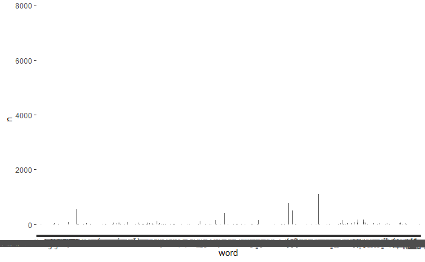

```r
word_counts_comments <- tidy_qtt_post %>%
  count(word) %>%
  arrange(desc(n))

ggplot(word_counts_comments, aes(x = word, y = n)) + geom_col()
```

## filter() before visualizing

The first problem is we are trying to plot way too many words at once. What we typically care about are the words with the largest counts. Right after using count() on the tidy text, we can filter based on the count n. Here we keep only those words used more than 1000 times. This cutoff will depend on the data.

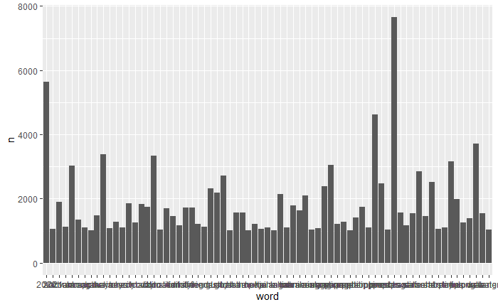

```r
word_counts_comments <- tidy_qtt_post %>%
  count(word) %>%
  filter(n > 1000) %>%
  arrange(desc(n))

ggplot(
  word_counts_comments, aes(x = word, y = n)) +
  geom_col()
```

## Using coord_flip()

The second problem was that the words overlapped and were hard to read on the x-axis. After geom_col(), we can add coord_flip(). This flips the coordinates of our plot so it’s easy to read our filtered set of word counts. For good measure, we use ggtitle() to explain what it is we’re plotting.

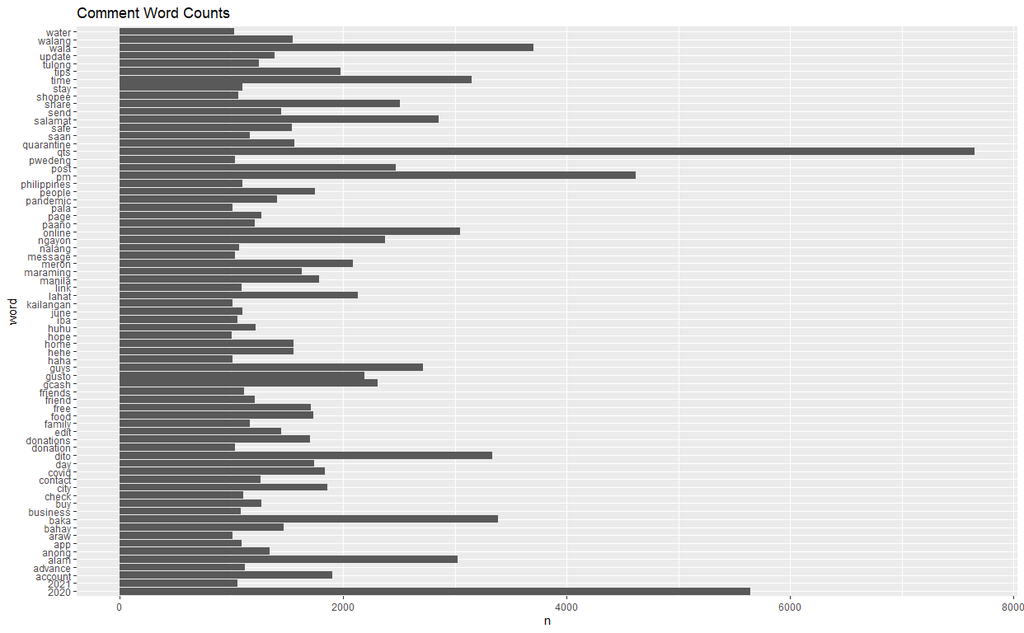

```r
ggplot(word_counts_comments, aes(x = word, y = n)) +
  geom_col() +
  coord_flip() +
  ggtitle("Comment Word Counts")
```

## Using fct_reorder()

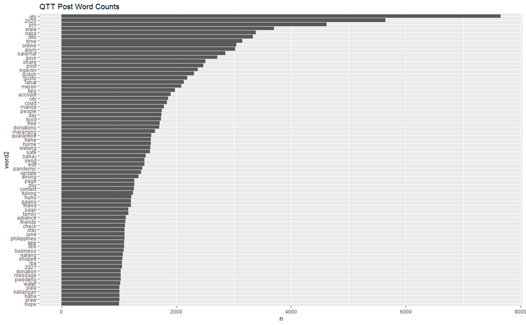

```r
word_counts_comments <- tidy_qtt_post %>%
  count(word) %>%
  filter(n > 1000) %>%
  mutate(word2 = fct_reorder(word, n))

ggplot(word_counts_comments, aes(x = word2, y = n)) +
  geom_col() +
  coord_flip() +
  ggtitle("QTT Post Word Counts")
```

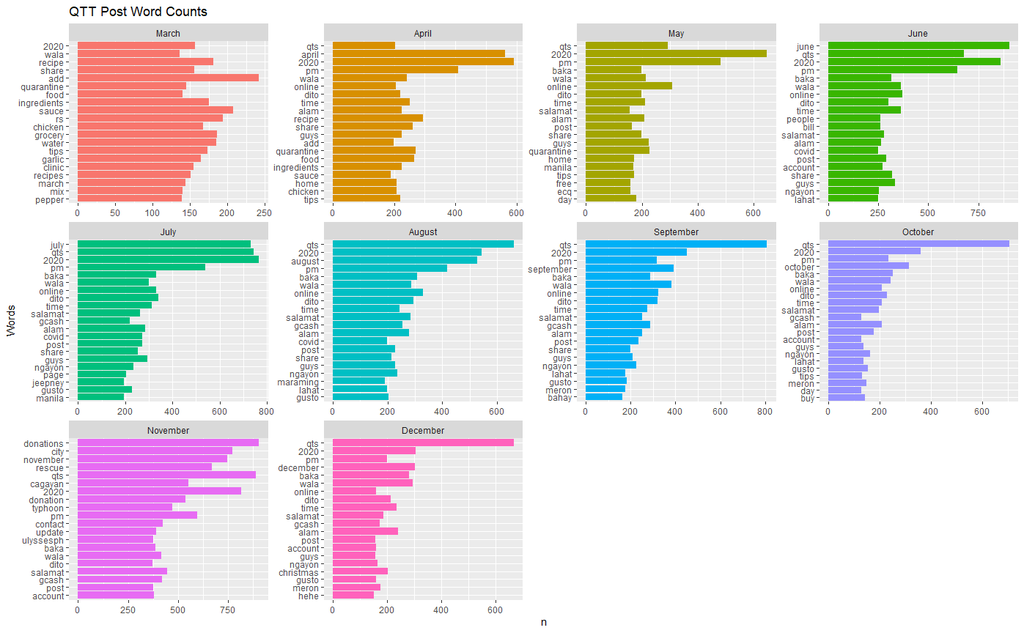

```r
tidy_qtt_post %>%
  filter(year == "2020") %>%
  count(word, month) %>%
  group_by(month)%>%
  top_n(20, n) %>%
  ggplot(aes(x = reorder(word, n), y = n, fill = month)) +
  geom_col(show.legend = FALSE) +
  facet_wrap(~month, scales = "free") +
  coord_flip() +
  labs(title = "QTT Post Word Counts",x = "Words")
```

# Reference

Feinerer, Ingo, et al. “Text Mining Infrastructure in r.” *Journal of Statistical Software*, vol. 25, no. 5, 2008, pp. 1–54, https://www.jstatsoft.org/v25/i05/.

Fellows, Ian. *Wordcloud: Word Clouds*. 2018, https://CRAN.R-project.org/package=wordcloud.

Grün, Bettina, and Kurt Hornik. “topicmodels: An R Package for Fitting Topic Models.” *Journal of Statistical Software*, vol. 40, no. 13, 2011, pp. 1–30, https://doi.org/10.18637/jss.v040.i13.

Hvitfeldt, Emil. *Textdata: Download and Load Various Text Datasets*. 2022, https://CRAN.R-project.org/package=textdata.

Neuwirth, Erich. *RColorBrewer: ColorBrewer Palettes*. 2022, https://CRAN.R-project.org/package=RColorBrewer.

R Core Team. *R: A Language and Environment for Statistical Computing*. R Foundation for Statistical Computing, 2022, https://www.R-project.org/.

RStudio Team. *RStudio: Integrated Development Environment for r*. RStudio, PBC, 2022, http://www.rstudio.com/.

Silge, Julia, and David Robinson. “Tidytext: Text Mining and Analysis Using Tidy Data Principles in r.” *JOSS*, vol. 1, no. 3, 2016, https://doi.org/10.21105/joss.00037.

Wickham, Hadley. “Reshaping Data with the reshape Package.” *Journal of Statistical Software*, vol. 21, no. 12, 2007, pp. 1–20, http://www.jstatsoft.org/v21/i12/.

Wickham, Hadley, et al. “Welcome to the tidyverse.” *Journal of Open Source Software*, vol. 4, no. 43, 2019, p. 1686, https://doi.org/10.21105/joss.01686.